# Prueba de Spark con R en el ambiente de IBM Watson

Este notebook es un ejercicio de prueba en el que usamos RStudio conectado a Spark para hacer un análisis de un conjunto de datos. Usaremos principalmente las librerías *sparklyr* y *tidyverse*, pero hay otras que también serán de gran utilidad.

### Conectando con Spark

En el Rstudio que corre en watson se puede revisar las instancias de Spark que se tienen disponibles en el ambiente de trabajo:

```r
library(sparklyr)
library(tidyverse)
library(caret)
library(ROCR)
list_spark_kernels()
```

```
## [1] "Apache Spark-o1"
```

```r
#Y guardamos esta información en una variable
inst <- list_spark_kernels()
```

Después de establecer la instancia podemos pasar a Spark el famoso archivo de datos de clientes de Telco:

```r
#library(dplyr)
#Leemos el csv de Telco y lo copiamos a Spark usando "dplyr", esto crea un data frame en Spark y una tabla temporal basada en el data frame local de R
telco_data <- read.csv("telco_data.csv")
#telco_muestra <- copy_to(sc, telco_data, "telco", overwrite = TRUE)
telco_tbl <- copy_to(sc, telco_data, "telco_tbl", overwrite = TRUE)
#telco_tbl <- spark_read_csv(sc, name="telco_tbl" , path="telco_data.csv")
src_tbls(sc)
```

```
## [1] "telco_tbl"
```

Hacemos una consulta tipo SQL para comprobar que tenemos datos en la tabla:

```r
# Notemos que la consulta es a la tabla generada en Spark: "telco" y no la que está en R que llamamos "telco_data"
library(DBI)
consulta <- dbGetQuery(sc, "SELECT * FROM telco_tbl")
str(consulta)
```

```
## 'data.frame':    7043 obs. of  21 variables:
##  $ customerID      : chr  "7590-VHVEG" "5575-GNVDE" "3668-QPYBK" "7795-CFOCW" ...
##  $ gender          : chr  "Female" "Male" "Male" "Male" ...
##  $ SeniorCitizen   : int  0 0 0 0 0 0 0 0 0 0 ...
##  $ Partner         : chr  "Yes" "No" "No" "No" ...
##  $ Dependents      : chr  "No" "No" "No" "No" ...
##  $ tenure          : int  1 34 2 45 2 8 22 10 28 62 ...
##  $ PhoneService    : chr  "No" "Yes" "Yes" "No" ...
##  $ MultipleLines   : chr  "No phone service" "No" "No" "No phone service" ...
##  $ InternetService : chr  "DSL" "DSL" "DSL" "DSL" ...
##  $ OnlineSecurity  : chr  "No" "Yes" "Yes" "Yes" ...
##  $ OnlineBackup    : chr  "Yes" "No" "Yes" "No" ...
##  $ DeviceProtection: chr  "No" "Yes" "No" "Yes" ...
##  $ TechSupport     : chr  "No" "No" "No" "Yes" ...
##  $ StreamingTV     : chr  "No" "No" "No" "No" ...
##  $ StreamingMovies : chr  "No" "No" "No" "No" ...
##  $ Contract        : chr  "Month-to-month" "One year" "Month-to-month" "One year" ...
##  $ PaperlessBilling: chr  "Yes" "No" "Yes" "No" ...
##  $ PaymentMethod   : chr  "Electronic check" "Mailed check" "Mailed check" "Bank transfer (automatic)" ...
##  $ MonthlyCharges  : num  29.9 57 53.9 42.3 70.7 ...
##  $ TotalCharges    : num  29.9 1889.5 108.2 1840.8 151.7 ...
##  $ Churn           : chr  "No" "No" "Yes" "No" ...
```

### Estudiamos los datos

```r
summary(telco_data)
```

```
##       customerID      gender     SeniorCitizen    Partner    Dependents
##  0002-ORFBO:   1   Female:3488   Min.   :0.0000   No :3641   No :4933
##  0003-MKNFE:   1   Male  :3555   1st Qu.:0.0000   Yes:3402   Yes:2110
##  0004-TLHLJ:   1                 Median :0.0000
##  0011-IGKFF:   1                 Mean   :0.1621
##  0013-EXCHZ:   1                 3rd Qu.:0.0000
##  0013-MHZWF:   1                 Max.   :1.0000
##  (Other)   :7037
##      tenure      PhoneService          MultipleLines     InternetService
##  Min.   : 0.00   No : 682     No              :3390   DSL        :2421
##  1st Qu.: 9.00   Yes:6361     No phone service: 682   Fiber optic:3096
##  Median :29.00                Yes             :2971   No         :1526
##  Mean   :32.37
##  3rd Qu.:55.00
##  Max.   :72.00
##
##              OnlineSecurity              OnlineBackup
##  No                 :3498   No                 :3088
##  No internet service:1526   No internet service:1526
##  Yes                :2019   Yes                :2429
##
##
##
##
##             DeviceProtection              TechSupport
##  No                 :3095    No                 :3473
##  No internet service:1526    No internet service:1526
##  Yes                :2422    Yes                :2044
##
##
##
##
##               StreamingTV              StreamingMovies
##  No                 :2810   No                 :2785
##  No internet service:1526   No internet service:1526
##  Yes                :2707   Yes                :2732
##
##
##
##
##            Contract    PaperlessBilling                   PaymentMethod
##  Month-to-month:3875   No :2872         Bank transfer (automatic):1544
##  One year      :1473   Yes:4171         Credit card (automatic)  :1522
##  Two year      :1695                    Electronic check         :2365
##                                         Mailed check             :1612
##
##
##
##  MonthlyCharges    TotalCharges    Churn
##  Min.   : 18.25   Min.   :  18.8   No :5174
##  1st Qu.: 35.50   1st Qu.: 401.4   Yes:1869
##  Median : 70.35   Median :1397.5
##  Mean   : 64.76   Mean   :2283.3
##  3rd Qu.: 89.85   3rd Qu.:3794.7
##  Max.   :118.75   Max.   :8684.8
##                   NA's   :11
```

Vemos que la columna *TotalCharges* contiene NA’s. También vemos que *Seniorcitizen* quizá es mejor que sea tipo factor:

```r
telco_data <- telco_data %>% mutate_if(is.character, as.factor)
telco_data$SeniorCitizen <- as.factor(telco_data$SeniorCitizen)
glimpse(telco_data)
```

```
## Observations: 7,043
## Variables: 21
## $ customerID       <fct> 7590-VHVEG, 5575-GNVDE, 3668-QPYBK, 7795-CFOC...
## $ gender           <fct> Female, Male, Male, Male, Female, Female, Mal...
## $ SeniorCitizen    <fct> 0, 0, 0, 0, 0, 0, 0, 0, 0, 0, 0, 0, 0, 0, 0, ...
## $ Partner          <fct> Yes, No, No, No, No, No, No, No, Yes, No, Yes...
## $ Dependents       <fct> No, No, No, No, No, No, Yes, No, No, Yes, Yes...
## $ tenure           <int> 1, 34, 2, 45, 2, 8, 22, 10, 28, 62, 13, 16, 5...
## $ PhoneService     <fct> No, Yes, Yes, No, Yes, Yes, Yes, No, Yes, Yes...
## $ MultipleLines    <fct> No phone service, No, No, No phone service, N...
## $ InternetService  <fct> DSL, DSL, DSL, DSL, Fiber optic, Fiber optic,...
## $ OnlineSecurity   <fct> No, Yes, Yes, Yes, No, No, No, Yes, No, Yes, ...
## $ OnlineBackup     <fct> Yes, No, Yes, No, No, No, Yes, No, No, Yes, N...
## $ DeviceProtection <fct> No, Yes, No, Yes, No, Yes, No, No, Yes, No, N...
## $ TechSupport      <fct> No, No, No, Yes, No, No, No, No, Yes, No, No,...
## $ StreamingTV      <fct> No, No, No, No, No, Yes, Yes, No, Yes, No, No...
## $ StreamingMovies  <fct> No, No, No, No, No, Yes, No, No, Yes, No, No,...
## $ Contract         <fct> Month-to-month, One year, Month-to-month, One...
## $ PaperlessBilling <fct> Yes, No, Yes, No, Yes, Yes, Yes, No, Yes, No,...
## $ PaymentMethod    <fct> Electronic check, Mailed check, Mailed check,...
## $ MonthlyCharges   <dbl> 29.85, 56.95, 53.85, 42.30, 70.70, 99.65, 89....
## $ TotalCharges     <dbl> 29.85, 1889.50, 108.15, 1840.75, 151.65, 820....
## $ Churn            <fct> No, No, Yes, No, Yes, Yes, No, No, Yes, No, N...
```

Para los valores faltantes, también podemos buscarlos de la siguiente forma:

```r
telco_data %>% map(~ sum(is.na(.)))
```

```
## $customerID
## [1] 0
##
## $gender
## [1] 0
##
## $SeniorCitizen
## [1] 0
##
## $Partner
## [1] 0
##
## $Dependents
## [1] 0
##
## $tenure
## [1] 0
##
## $PhoneService
## [1] 0
##
## $MultipleLines
## [1] 0
##
## $InternetService
## [1] 0
##
## $OnlineSecurity
## [1] 0
##
## $OnlineBackup
## [1] 0
##
## $DeviceProtection
## [1] 0
##
## $TechSupport
## [1] 0
##
## $StreamingTV
## [1] 0
##
## $StreamingMovies
## [1] 0
##
## $Contract
## [1] 0
##
## $PaperlessBilling
## [1] 0
##
## $PaymentMethod
## [1] 0
##
## $MonthlyCharges
## [1] 0
##
## $TotalCharges
## [1] 11
##
## $Churn
## [1] 0
```

Vamos a reemplazar los valores faltantes por la mediana:

```r
telco_data <- telco_data %>%
  mutate(TotalCharges = replace(TotalCharges,
                                is.na(TotalCharges),
                                median(TotalCharges, na.rm = T)))
sum(is.na(telco_data$TotalCharges))
```

```
## [1] 0
```

### Exploración

Quizás vale la pena visualizar algunas de las variables categóricas para ver si son estados con cargos totales altos y si acaso son estados en los que los clientes abandonaron el servicio:

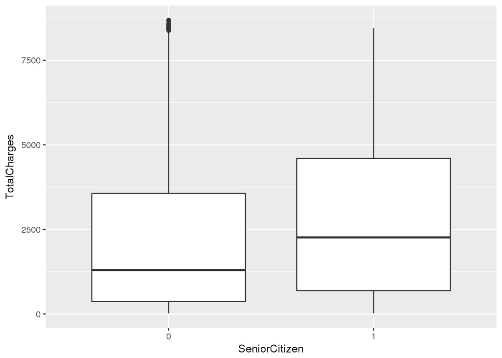

```r
# Jubilados
ggplot(telco_data, aes(x = SeniorCitizen, y = TotalCharges)) +
  geom_boxplot()
```

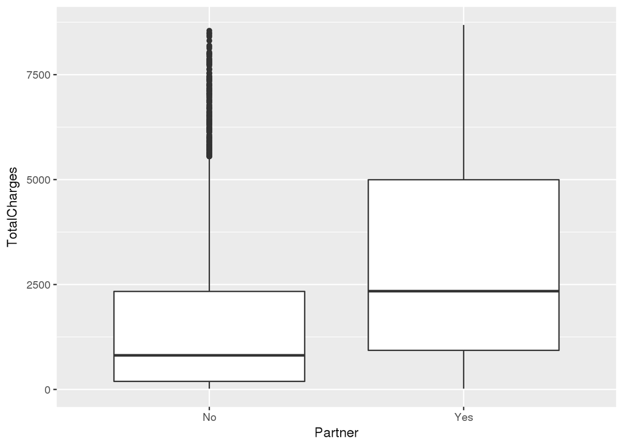

```r
# Con Partner
ggplot(telco_data, aes(x = Partner, y = TotalCharges)) +
  geom_boxplot()
```

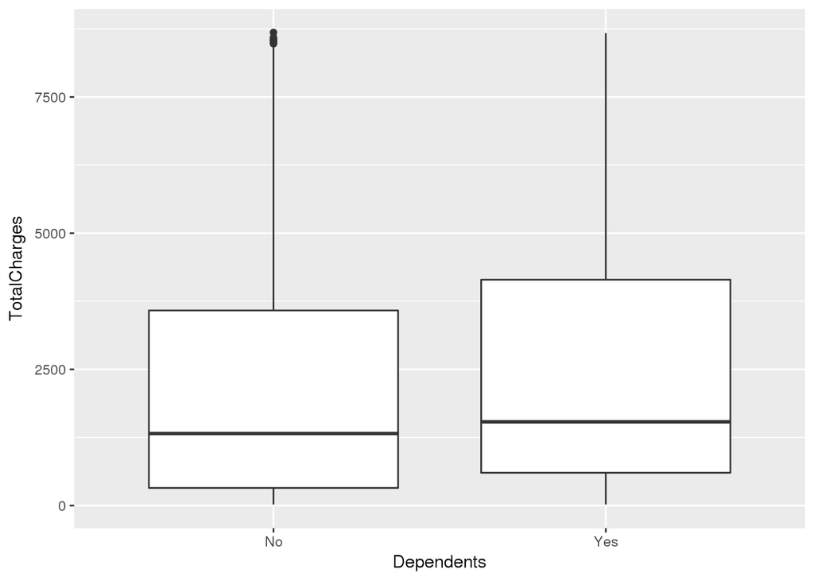

```r
# Con Dependents
ggplot(telco_data, aes(x = Dependents, y = TotalCharges)) +
  geom_boxplot()
```

Al explorar estas variables, vemos que quizá debemos comparar los cargos totales de los jubilados, de gente sin pareja y sin dependientes.

```r
# Caso de jubilados y el promedio de tiempo con el servicio
telco_data %>%
  select(SeniorCitizen, Churn, TotalCharges, tenure) %>%
  filter(SeniorCitizen == 1, Churn == "Yes") %>%
  summarize(n = n(),
            total = sum(TotalCharges),
            avg_tenure = sum(tenure)/n)
```

| n | total | avg_tenure |
| --- | --- | --- |
| 476 | 882405.2 | 21.03361 |

```r
# Caso de clientes sin pareja y el promedio de tiempo con el servicio
telco_data %>%
  select(Partner, Churn, TotalCharges, tenure) %>%
  filter(Partner == "No", Churn == "Yes") %>%
  summarise(n = n(),
            total = sum(TotalCharges),
            avg_tenure = sum(tenure)/n)
```

| n | total | avg_tenure |
| --- | --- | --- |
| 1200 | 1306776 | 13.17667 |

```r
# Caso de clientes sin pareja y el promedio de tiempo con el servicio
telco_data %>%
  select(Dependents, Churn, TotalCharges, tenure) %>%
  filter(Dependents == "No", Churn == "Yes") %>%
  summarise(n = n(),
            total = sum(TotalCharges),
            avg_tenure = sum(tenure)/n)
```

| n | total | avg_tenure |
| --- | --- | --- |
| 1543 | 2261840 | 17.12314 |

### Regresión Logística

Vamos a ajustar un modelo de regresión:

```r
#En este momento el ID no es importante
telco_data <- telco_data %>% select(-customerID)

set.seed(2018)

Entrena <- createDataPartition(y = telco_data$Churn, p=0.75, list=FALSE)

train <- telco_data[Entrena,]
test <- telco_data[-Entrena,]

# La regresión logística se conoce también como regresión lineal generalizada, por eso el nombre glm
logfit <- glm(Churn~., data=train, family=binomial)

# Inferencia
proba_de_churn <- predict(logfit, test, type="response")
head(proba_de_churn)
```

```
##          1          4          7         11         12         25
## 0.62962828 0.02737274 0.50623777 0.19620531 0.02912353 0.02975828
```

Con lo anterior podemos analizar si el ajuste ha sido adecuado.

```r
glm.pred = rep("No", length(proba_de_churn))
glm.pred[proba_de_churn > 0.5] = "Yes"

confusionMatrix(factor(glm.pred), factor(test$Churn), positive = "Yes")
```

```
## Confusion Matrix and Statistics
##
##           Reference
## Prediction   No  Yes
##        No  1170  195
##        Yes  123  272
##
##                Accuracy : 0.8193
##                  95% CI : (0.8005, 0.837)
##     No Information Rate : 0.7347
##     P-Value [Acc > NIR] : < 2.2e-16
##
##                   Kappa : 0.5126
##  Mcnemar's Test P-Value : 6.849e-05
##
##             Sensitivity : 0.5824
##             Specificity : 0.9049
##          Pos Pred Value : 0.6886
##          Neg Pred Value : 0.8571
##              Prevalence : 0.2653
##          Detection Rate : 0.1545
##    Detection Prevalence : 0.2244
##       Balanced Accuracy : 0.7437
##
##        'Positive' Class : Yes
##
```

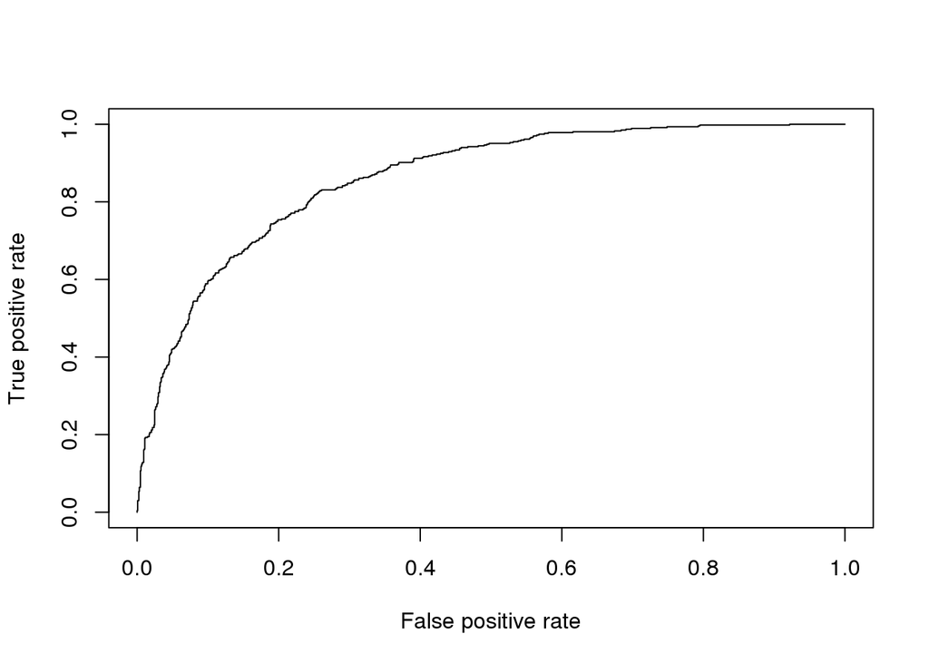

```r
pr <- prediction(proba_de_churn, test$Churn)

prf <- performance(pr, measure = "tpr", x.measure = "fpr")
plot(prf)
```

```r
auc <- performance(pr, measure = "auc")
auc <- auc@y.values[[1]]
auc
```

```
## [1] 0.8607789
```

### Referencias

1. http://rstudio.github.io/sparklyr/articles/guides-dplyr.html